# hw_cnn

kzaitsev

June 18, 2017

```r
library(OpenImageR)
```

## Данные

Данные, которые легли в основу этой домашки взяты из статьи http://image.diku.dk/lauges/publications/Sorensen2010.pdf , которая лежит в архиве с домашним заданием. Авторы данной статьи занимались квантификацией легочной эмфиземы, в связи с чем у этих ребят было некоторое количество изображений компьютерной томографии легких.

Мы будем с вами классифицировать кусочки изображений на три класса: normal tissue (NT), centrilobular emphysema (CLE), paraseptal emphysema (PSE).

Картинки по которым будем производить классификацию находятся в папке “patches”, для работы с изображениями будем использовать библиотеку OpenImageR.

## Часть 1. Увеличение количества картинок

В папке “patches” находится 168 jpg изображений размера 61x61. Этого количества, конечно, мало, поэтому было бы неплохо это количество увеличить. Как будем увеличивать? Картинку можно повернуть на какое-то количество градусов и зеркально отразить. Можно сдвинуть картинку на несколько пикселей. А ещё было бы неплохо применить ZCA whitening (подробнее можно почитать здесь https://en.wikipedia.org/wiki/Whitening_transformation) – это такое нормализующее преобразование, которое часто используется в обучении нейронных сетей.

Первой частью нашего задания будет искусственное увеличение датасета с помощью функции Augmentation в пакете OpenImageR: хочется взять и каждую картинку случайно повернуть и немного сдвинуть и проделать это где-то ~50 раз.

Пример использования функции ниже:

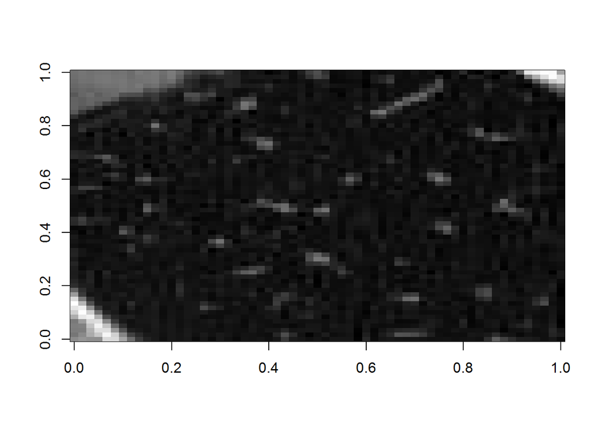

```r
# taken from https://stackoverflow.com/questions/22509106/converting-a-matrix-into-a-gray-scale-image-in-r
grays = rgb(red = 0:255/255, blue = 0:255/255, green = 0:255/255)

patch <- readImage("patches/patch1.jpg")
image(patch, col=grays)
```

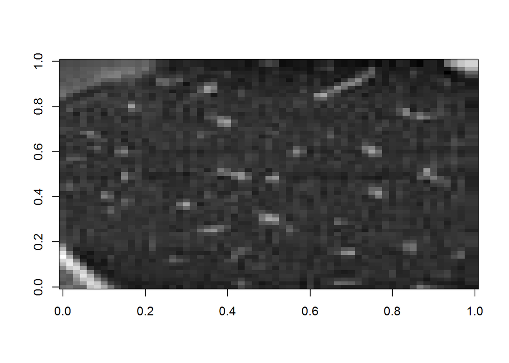

```r
# ZCA only
patchAugmented <-   Augmentation(patch, zca_comps = 30, zca_epsilon = 0.1, threads = 1, verbose = F)
image(patchAugmented, col=grays)
```

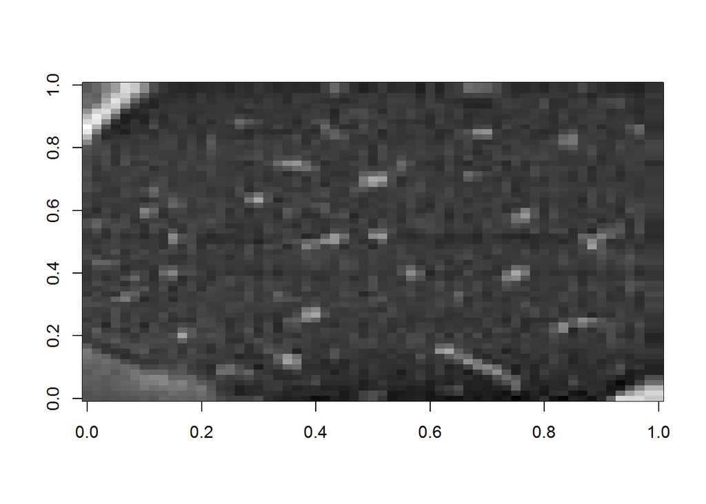

```r
# ZCA only + flip
patchAugmented <-   Augmentation(patch, flip_mode = "horizontal",
                                 zca_comps = 30, zca_epsilon = 0.1, threads = 1, verbose = F)
image(patchAugmented, col=grays)
```

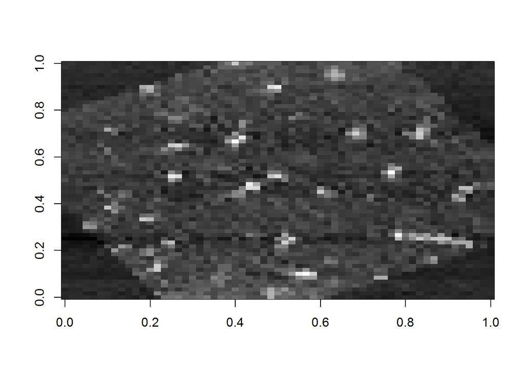

```r
# ZCA only + flip + rotation 30 degrees counterclockwise
patchAugmented <-   Augmentation(patch, flip_mode = "horizontal",
             rotate_angle = 30, rotate_method = 'bilinear',
             zca_comps = 30,zca_epsilon = 0.1, threads = 1, verbose = F)
image(patchAugmented, col=grays)
```

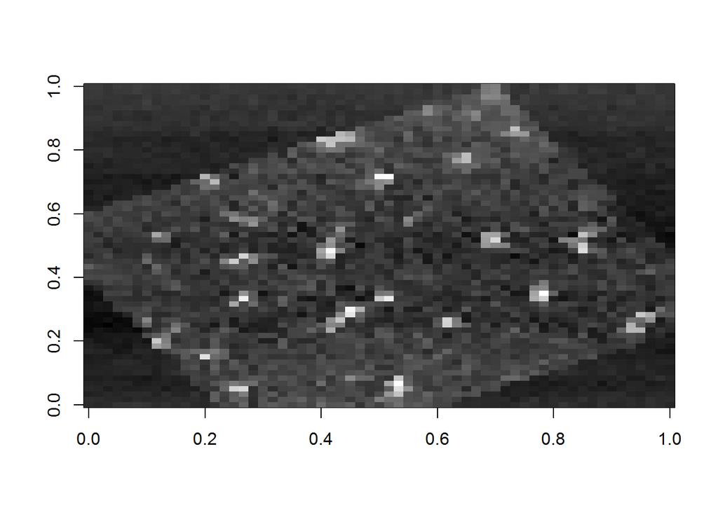

```r
# ZCA only + flip + rotation 30 degrees counterclockwise + shift 10 pixels comlumns and 5 pixels rows
patchAugmented <-   Augmentation(patch, flip_mode = "horizontal",
             shift_cols = 10, shift_rows = 5,
             rotate_angle = 30, rotate_method = 'bilinear',
             zca_comps = 30,zca_epsilon = 0.1, threads = 1, verbose = F)
image(patchAugmented, col=grays)
```

## Данные

В папке `patches` лежат маленькие картинки – части изображений легких. В папке `slices` лежат изорабражения срезов легких целиком. В файле `patch_labels.csv` лежит 168 чисел от 0 до 2: 0 for normal tissue (NT), 1 for centrilobular emphysema (CLE), 2 for paraseptal emphysema (PSE), описывает класс каждого изображения из папки `patches`. Вообще все эти слайсы и патчи от реальных пациентов, и там есть файлики, которые описывают это всё дело, но нас в этой работе будут интересовать только patches и patch_labels.

## Часть вторая

Хочется взять разбить 168 картинок на тренировочную и тестирущие выборки: 34 в тестирующей и 134 в тренировочной. Тогда воспользуемся результатами предыдущего шага $134 \times 50$ картинок – тренировочная выборка, $34 \times 50$ – тестирующая. Хочется обучить нейронную сеть, как мы делали на паре.

Из советов: советую запускать обучение со следующими параметрами:

```r
mx.set.seed(1)
model <- mx.model.FeedForward.create(NN_model,
                                     X=train.array,
                                     y=as.array(nn.train.y-1),
                                     eval.data = list(
                                       data=test.array,
                                       label=as.array(nn.test.y-1)
                                     ),
                                     ctx=mx.cpu(),
                                     num.round = 100,
                                     optimizer="adadelta",
                                     eval.metric = mx.metric.accuracy,
                                     epoch.end.callback = mx.callback.log.train.metric(10))
```

`eval.data` содержит в себе валидирующие данные, такой запуск поможет нам сразу смотреть на ошибку train/test при обучении. `optimiser="adedelta"` сходится чуть быстрее чем стохастический градиентный спуск. `eval.metric` нам нужен ’accuracy` ибо мы решаем задачу классификации, а epoch.end.callback – указывает, что нам бы показывать ошибку во время итераций.

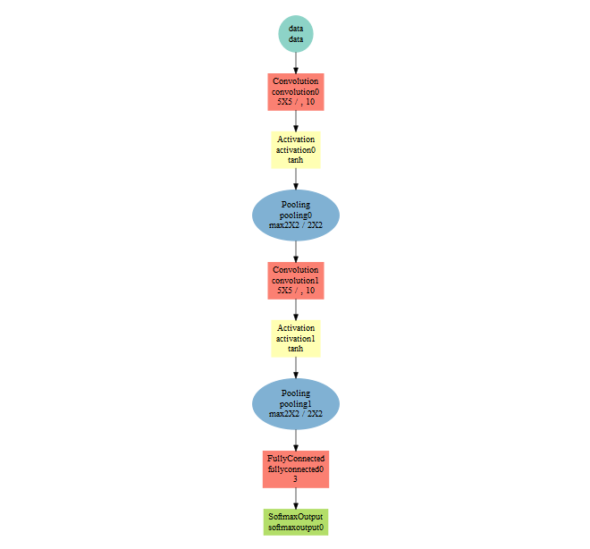